# Final_Project_Part_2_D

Peng Yuan

2023-04-18

## Train/tune with resampling

### Load package and Data

```r
library(tidyverse)
library(caret)
```

```r
library(coefplot)
library(rstanarm)
library(splines)
library(kernlab)
df <- readr::read_csv("paint_project_train_data.csv", col_names = TRUE)
dfii_ready <- df %>%
  mutate(y = boot::logit( (response - 0) / (100 - 0) ) ) %>%
  subset(select = c(R, G, B,
         Lightness, Saturation, Hue,response,
         y))

dfii <- dfii_ready %>%
  subset(select = c(R, G, B, Hue)) %>%
  scale() %>% as.data.frame() %>%
  bind_cols(dfii_ready %>% subset(select = c(Lightness, Saturation, y)))



dfii %>% glimpse()
```

```
## Rows: 835
## Columns: 7
## $ R          <dbl> -0.19790120, -2.74419521, -0.19790120, -2.70931447, -0.2327…
## $ G          <dbl> -2.3619736, -1.7631189, -1.6433480, -1.7830807, -2.2022790,…
## $ B          <dbl> -1.7994266, -0.1706872, -1.8726283, -0.1523868, -1.8726283,…
## $ Hue        <dbl> -1.3548215, 1.3198239, -0.9585777, 1.4188848, -1.2557605, -…
## $ Lightness  <chr> "dark", "dark", "dark", "dark", "dark", "dark", "dark", "da…
## $ Saturation <chr> "bright", "bright", "bright", "bright", "bright", "bright",…
## $ y          <dbl> -1.9924302, -2.1972246, -1.6582281, -2.1972246, -2.0907411,…
```

### Train Model

```r
my_ctrl <- trainControl(method = "repeatedcv", number = 5, repeats = 3)
my_metric <- "RMSE"
```

#### Linear models

All categorical and continuous inputs - linear additive features

```r
set.seed(1234)
fit_lm_add <- train(y ~ R + G + B + Hue + Lightness + Saturation,
                  data = dfii,
                  method = "lm",
                  metric = my_metric,
                  preProcess = c("center", "scale"),
                  trControl = my_ctrl)

fit_lm_add
```

```
## Linear Regression
##
## 835 samples
##   6 predictor
##
## Pre-processing: centered (16), scaled (16)
## Resampling: Cross-Validated (5 fold, repeated 3 times)
## Summary of sample sizes: 668, 668, 668, 668, 668, 668, ...
## Resampling results:
##
##   RMSE       Rsquared   MAE
##   0.0895452  0.9943403  0.0672197
##
## Tuning parameter 'intercept' was held constant at a value of TRUE
```

**Add categorical inputs to all main effect and all pairwise interactions of continuous inputs**

```r
set.seed(1234)
fit_lm_pair <- train(y ~ Lightness + Saturation + (R + G + B + Hue)^2,
                  data = dfii,
                  method = "lm",
                  metric = my_metric,
                  preProcess = c("center", "scale"),
                  trControl = my_ctrl)

fit_lm_pair
```

```
## Linear Regression
##
## 835 samples
##   6 predictor
##
## Pre-processing: centered (22), scaled (22)
## Resampling: Cross-Validated (5 fold, repeated 3 times)
## Summary of sample sizes: 668, 668, 668, 668, 668, 668, ...
## Resampling results:
##
##   RMSE        Rsquared   MAE
##   0.08068829  0.9954052  0.06083307
##
## Tuning parameter 'intercept' was held constant at a value of TRUE
```

**The 2 models selected from iiA) (if they are not one of the two above)**

```r
set.seed(1234)
fit_lm_mod6 <- train(y ~ (R + G + B + Hue)^2 + (Saturation + Lightness),
                  data = dfii,
                  method = "lm",
                  metric = my_metric,
                  preProcess = c("center", "scale"),
                  trControl = my_ctrl)

fit_lm_mod6
```

```
## Linear Regression
##
## 835 samples
##   6 predictor
##
## Pre-processing: centered (22), scaled (22)
## Resampling: Cross-Validated (5 fold, repeated 3 times)
## Summary of sample sizes: 668, 668, 668, 668, 668, 668, ...
## Resampling results:
##
##   RMSE        Rsquared   MAE
##   0.08068829  0.9954052  0.06083307
##
## Tuning parameter 'intercept' was held constant at a value of TRUE
```

```r
set.seed(1234)
fit_lm_mod2 <- train(y ~ R + G + B + Hue,
                  data = dfii,
                  method = "lm",
                  metric = my_metric,
                  preProcess = c("center", "scale"),
                  trControl = my_ctrl)

fit_lm_mod2
```

```
## Linear Regression
##
## 835 samples
##   4 predictor
##
## Pre-processing: centered (4), scaled (4)
## Resampling: Cross-Validated (5 fold, repeated 3 times)
## Summary of sample sizes: 668, 668, 668, 668, 668, 668, ...
## Resampling results:
##
##   RMSE       Rsquared   MAE
##   0.1300133  0.9880396  0.1021442
##
## Tuning parameter 'intercept' was held constant at a value of TRUE
```

#### Regularized regression with Elastic net

Add categorical inputs to all main effect and all pairwise interactions of continuous inputs

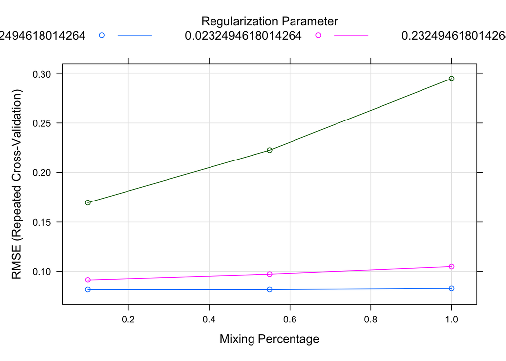

```r
set.seed(1234)
fit_enet_pair_warmup <- train(y ~ Lightness + Saturation + (R + G + B + Hue)^2,
                    data = dfii,
                    method = "glmnet",
                    metric = my_metric,
                    preProcess = c("center", "scale"),
                    trControl = my_ctrl)

plot(fit_enet_pair_warmup)
```

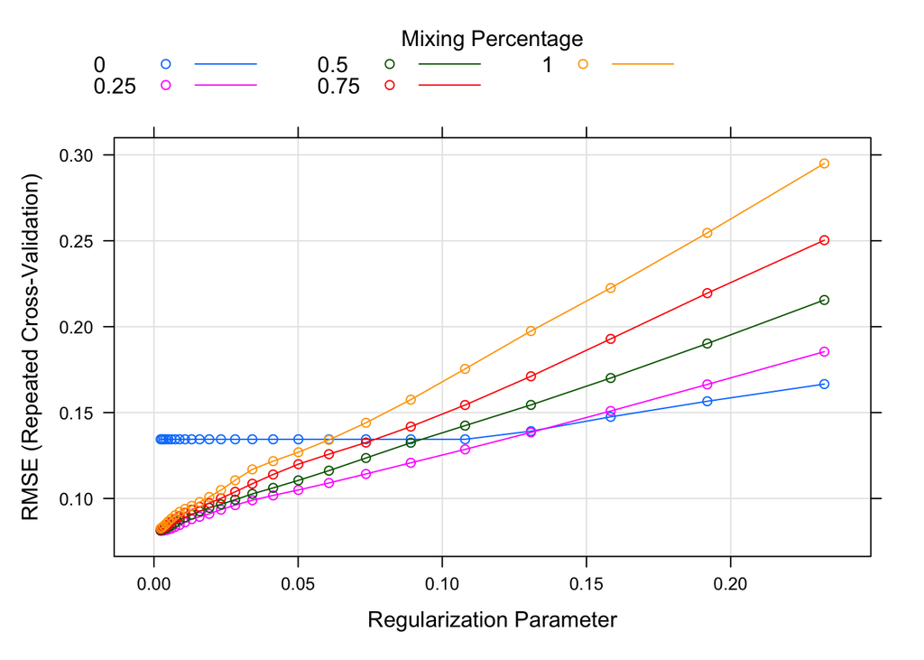

```r
tune_grid_add <- expand.grid(.alpha = seq(0, 1, length.out = 5),
                         .lambda = exp(
                          seq(log(min(fit_enet_pair_warmup$results$lambda)),
                          log(max(fit_enet_pair_warmup$results$lambda)),
                          length.out = 25)))

set.seed(1234)
fit_enet_pair_add <- train(y ~ Lightness + Saturation + (R + G + B + Hue)^2,
                    data = dfii,
                    method = "glmnet",
                    metric = my_metric,
                    tuneGrid = tune_grid_add,
                    preProcess = c("center", "scale"),
                    trControl = my_ctrl)

plot(fit_enet_pair_add)
```

```r
enet_pair_besttune <- fit_enet_pair_add$bestTune
enet_pair_tune_rmse <- fit_enet_pair_add$results[
  fit_enet_pair_add$results$alpha == fit_enet_pair_add$bestTune$alpha &
  fit_enet_pair_add$results$lambda == fit_enet_pair_add$bestTune$lambda,
  "RMSE"]
enet_pair_besttune
```

```
##    alpha      lambda
## 26  0.25 0.002324946
```

```r
enet_pair_tune_rmse
```

```
## [1] 0.08122426
```

For the Elastic net - pair model,the best alpha is 0.25 and lambda is 0.0023. In this condition, the rmse is 0.08.

The more complex of the 2 models selected from iiA)

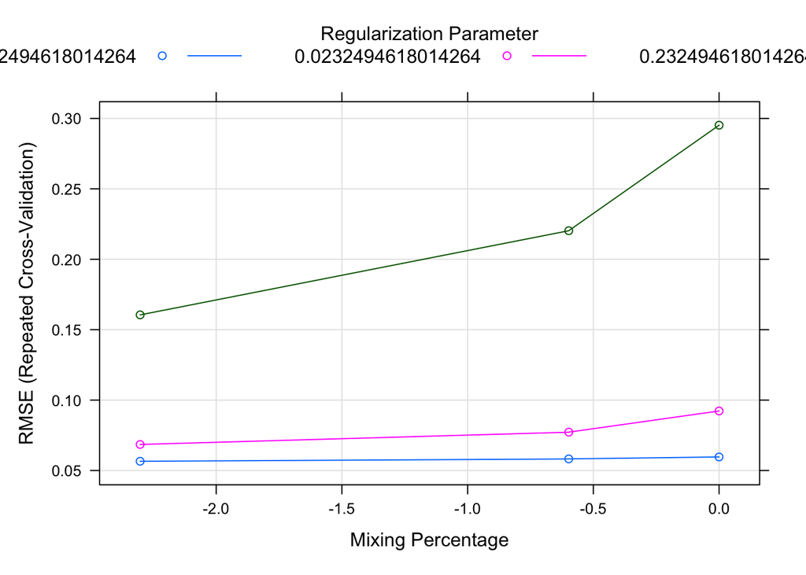

```r
fit_enet_mod10_warmup <- train(y ~ (I(R^2) + I(G^2) + I(B^2) + I(Hue^2) + R * G * B * Hue) + (Saturation * Lightness),
                    data = dfii,
                    method = "glmnet",
                    metric = my_metric,
                    preProcess = c("center", "scale"),
                    trControl = my_ctrl)

plot(fit_enet_mod10_warmup, xTrans = log)
```

**Tune**

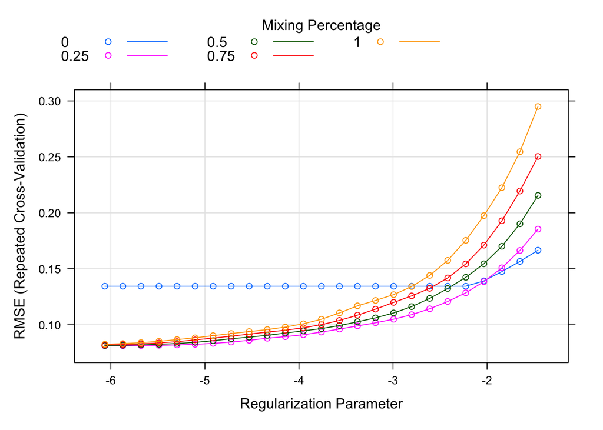

```r
set.seed(1234)
tune_grid_mod10 <- expand.grid(.alpha = seq(0, 1, length.out = 5),
                         .lambda = exp(
                          seq(log(min(fit_enet_mod10_warmup$results$lambda)),
                          log(max(fit_enet_mod10_warmup$results$lambda)),
                          length.out = 25)))

fit_enet_mod10_tune <- train(y ~ Lightness + Saturation + (R + G + B + Hue)^2,
                    data = dfii,
                    method = "glmnet",
                    metric = my_metric,
                    tuneGrid = tune_grid_mod10,
                    preProcess = c("center", "scale"),
                    trControl = my_ctrl)

plot(fit_enet_mod10_tune, xTrans = log)
```

```r
enet_pair_mod10_besttune <- fit_enet_mod10_tune$bestTune
enet_pair_mod10_tune_rmse <- fit_enet_mod10_tune$results[
  fit_enet_mod10_tune$results$alpha == fit_enet_mod10_tune$bestTune$alpha &
  fit_enet_mod10_tune$results$lambda == fit_enet_mod10_tune$bestTune$lambda,
  "RMSE"]
enet_pair_mod10_besttune
```

```
##    alpha      lambda
## 26  0.25 0.002324946
```

```r
enet_pair_mod10_tune_rmse
```

```
## [1] 0.08122426
```

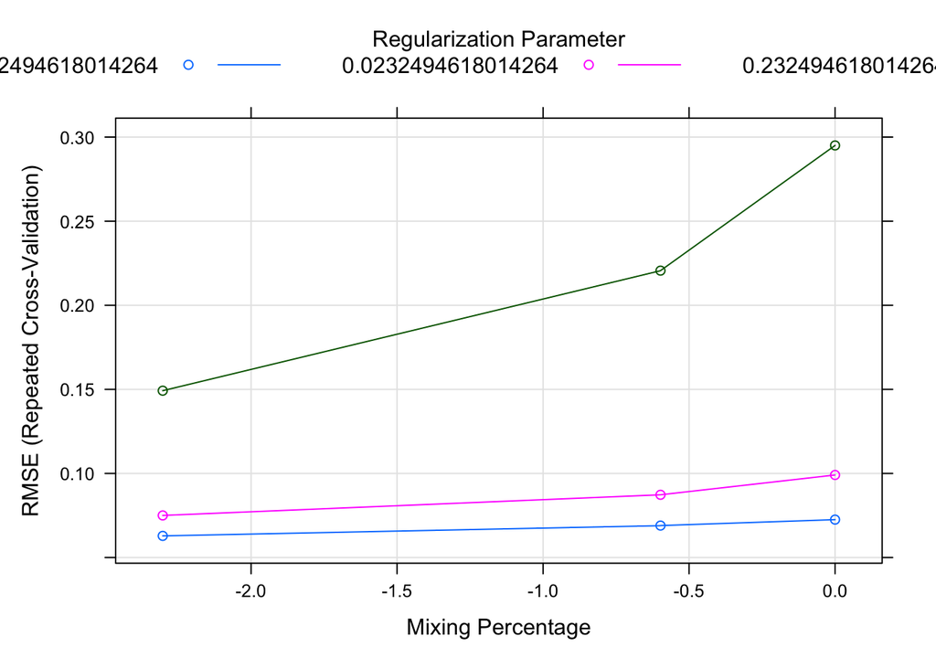

```r
set.seed(1234)
fit_enet_mod5_warmup <- train(y ~ (R + G + B + Hue) * (Saturation + Lightness),
                       data = dfii,
                       method = "glmnet",
                       metric = my_metric,
                       preProcess = c("center", "scale"),
                       trControl = my_ctrl)

plot(fit_enet_mod5_warmup, xTrans = log)
```

**Tune**

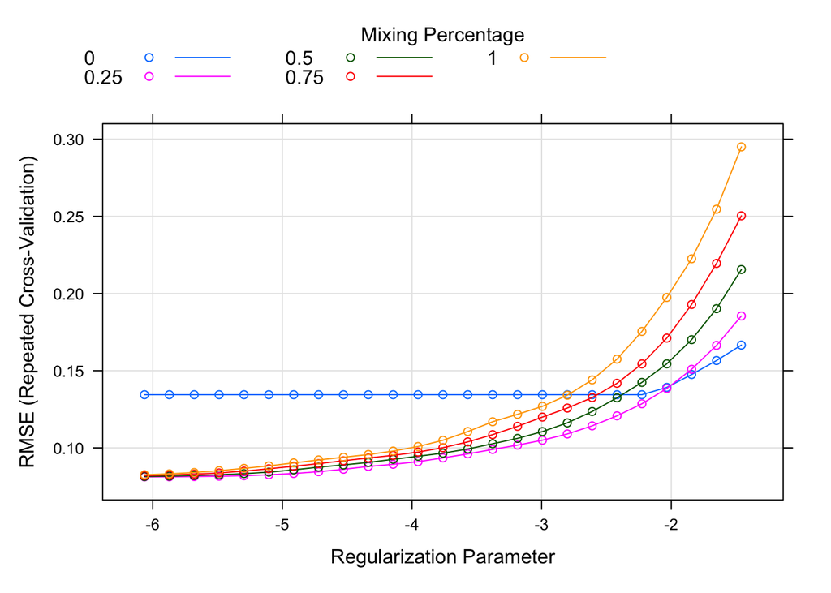

```r
set.seed(1234)
tune_grid_mod5 <- expand.grid(.alpha = seq(0, 1, length.out = 5),
                         .lambda = exp(
                          seq(log(min(fit_enet_mod5_warmup$results$lambda)),
                          log(max(fit_enet_mod5_warmup$results$lambda)),
                          length.out = 25)))

fit_enet_mod5_tune <- train(y ~ Lightness + Saturation + (R + G + B + Hue)^2,
                    data = dfii,
                    method = "glmnet",
                    metric = my_metric,
                    tuneGrid = tune_grid_mod5,
                    preProcess = c("center", "scale"),
                    trControl = my_ctrl)

plot(fit_enet_mod5_tune, xTrans = log)
```

```r
enet_pair_mod5_besttune <- fit_enet_mod5_tune$bestTune
enet_pair_mod5_tune_rmse <- fit_enet_mod5_tune$results[
  fit_enet_mod5_tune$results$alpha == fit_enet_mod5_tune$bestTune$alpha &
  fit_enet_mod5_tune$results$lambda == fit_enet_mod5_tune$bestTune$lambda,
  "RMSE"]
enet_pair_mod5_besttune
```

```
##    alpha      lambda
## 26  0.25 0.002324946
```

```r
enet_pair_mod5_tune_rmse
```

```
## [1] 0.08122426
```

#### Neural network

```r
set.seed(1234)

fit_nnet_warmup <- train(y ~ R + G + B + Hue + Saturation + Lightness,
                    data = dfii,
                    method = "nnet",
                    metric = my_metric,
                    preProcess = c("center", "scale"),
                    trControl = my_ctrl,
                    trace = FALSE,
                    linout = TRUE)
```

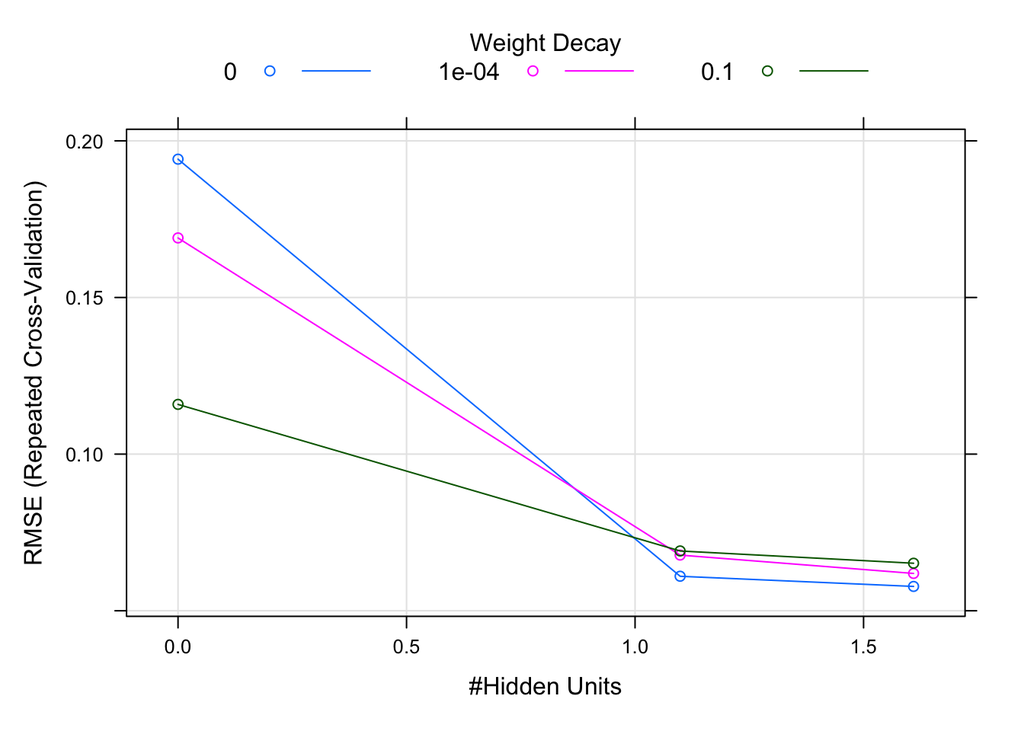

```r
plot(fit_nnet_warmup, xTrans = log)
```

**Tunning Grid model**

```r
tune_grid_neural <- expand.grid(size = c(5, 10, 20),
                                decay = c(0, 0.05, 0.1, 1, 2))

fit_nnet_tune <- train(y ~ R + G + B + Hue + Saturation + Lightness,
                    data = dfii,
                    method = "nnet",
                    metric = my_metric,
                    tuneGrid = tune_grid_neural,
                    preProcess = c("center", "scale"),
                    trControl = my_ctrl,
                    trace = FALSE,
                    linout = TRUE)


fit_nnet_besttune <- fit_nnet_tune$bestTune
fit_nnet_tune_rmse <- fit_nnet_tune$results[
  fit_nnet_tune$results$size == fit_nnet_tune$bestTune$size &
  fit_nnet_tune$results$decay == fit_nnet_tune$bestTune$decay,
  "RMSE"]
fit_nnet_besttune
```

```
##   size decay
## 6   10     0
```

```r
fit_nnet_tune_rmse
```

```
## [1] 0.05354339
```

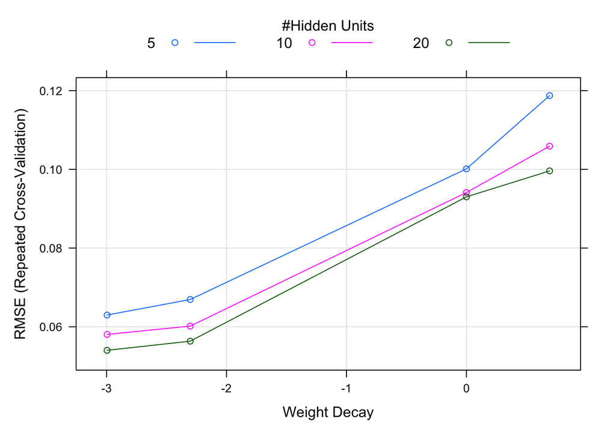

```r
plot(fit_nnet_tune, xTrans = log)
```

#### Random Forest

```r
set.seed(1234)
fit_rf_warmup <- train(y ~ R + G + B + Hue + Saturation + Lightness,
                     data = dfii,
                     method = "rf",
                     metric = "RMSE",
                     trControl = my_ctrl,
                     importance = TRUE)

fit_rf_warmup
```

```
## Random Forest
##
## 835 samples
##   6 predictor
##
## No pre-processing
## Resampling: Cross-Validated (5 fold, repeated 3 times)
## Summary of sample sizes: 668, 668, 668, 668, 668, 668, ...
## Resampling results across tuning parameters:
##
##   mtry  RMSE        Rsquared   MAE
##    2    0.22866751  0.9758253  0.16725791
##    9    0.07009182  0.9966400  0.05197140
##   16    0.08603203  0.9947627  0.06224873
##
## RMSE was used to select the optimal model using the smallest value.
## The final value used for the model was mtry = 9.
```

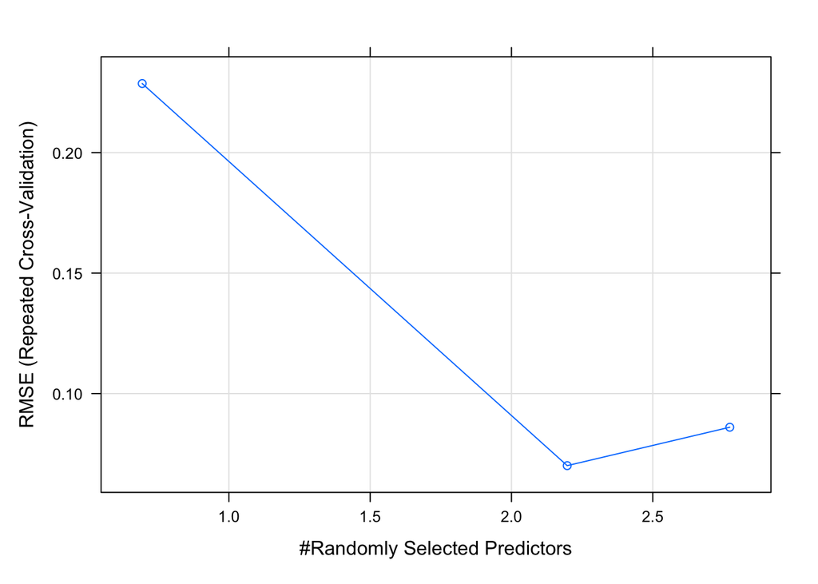

```r
plot(fit_rf_warmup, xTrans = log)
```

**Tune**

```r
set.seed(1234)
fit_rf_tune <- train(y ~ R + G + B + Hue + Saturation + Lightness,
                     data = dfii,
                     method = "rf",
                     metric = "RMSE",
                     trControl = my_ctrl,
                     tuneGrid = expand.grid(mtry = seq(2, 8, by = 1)),
                     importance = TRUE)
```

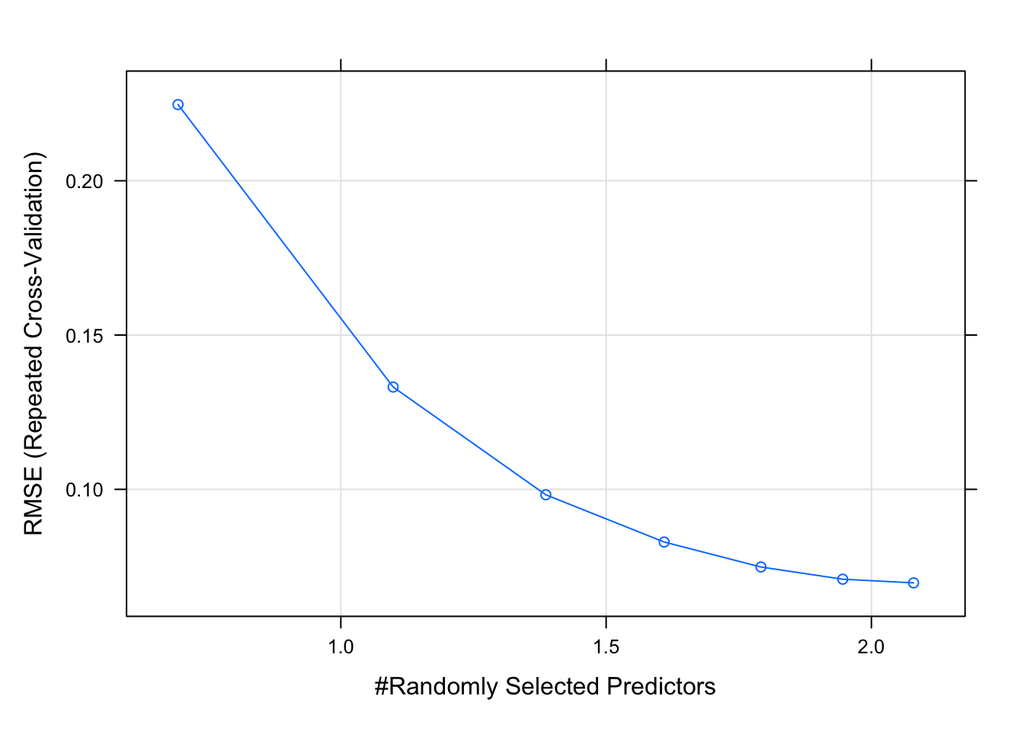

```r
plot(fit_rf_tune, xTrans = log)
```

#### Gradient Boosted Tree

```r
set.seed(1234)
fit_gbm_warmup <- train(y ~ R + G + B + Hue + Saturation + Lightness,
                      data = dfii,
                      method = "gbm",
                      metric = my_metric,
                      trControl = my_ctrl,
                      verbose=FALSE)
```

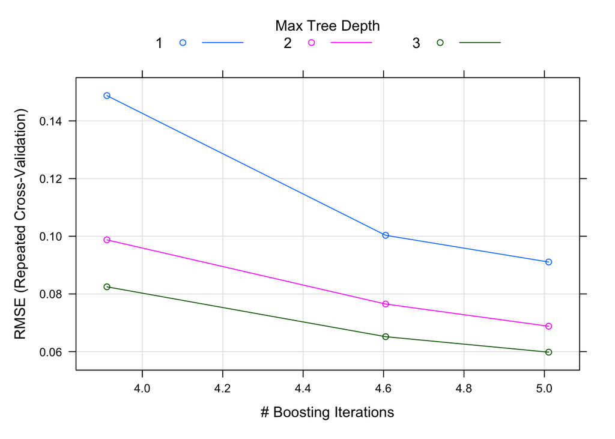

```r
plot(fit_gbm_warmup, xTrans = log)
```

**Tunning GBM model**

```r
gbm_grid <- expand.grid(n.trees = c(100, 150, 300, 500, 750, 1000),
                        shrinkage = c(0.01, 0.1),
                        interaction.depth = fit_gbm_warmup$bestTune$interaction.depth,
                        n.minobsinnode = fit_gbm_warmup$bestTune$n.minobsinnode)

set.seed(1234)
fit_gbm_tune <- train(y ~ R + G + B + Hue + Saturation + Lightness,
                      data = dfii,
                      method = "gbm",
                      metric = my_metric,
                      tuneGrid = gbm_grid,
                      trControl = my_ctrl,
                      verbose=FALSE)
```

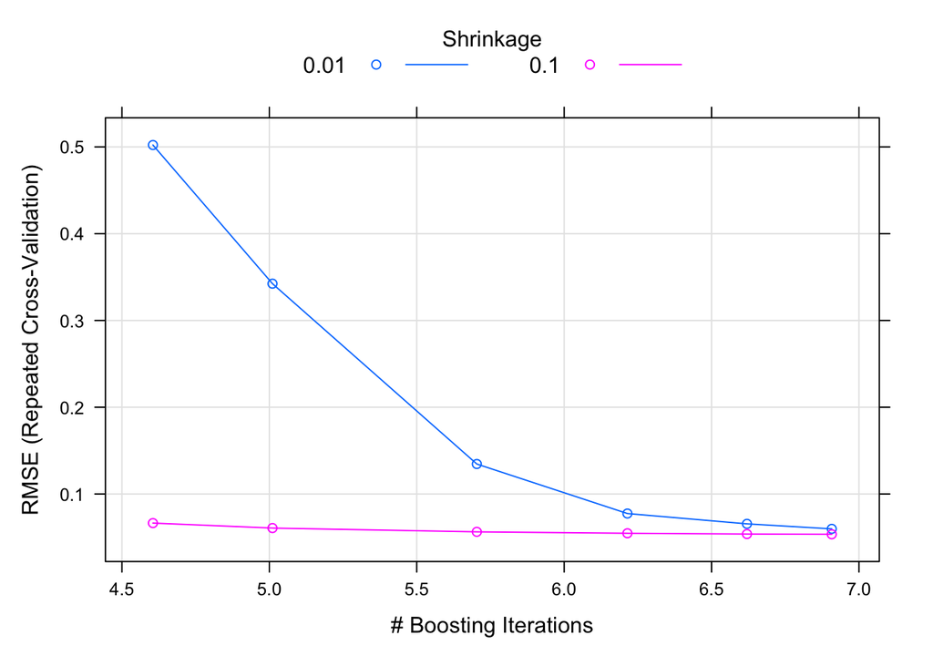

```r
plot(fit_gbm_tune, xTrans = log)
```

#### SVM

```r
set.seed(1234)
fit_svm_warmup <- train(y ~ R + G + B + Hue + Saturation + Lightness,
                      data = dfii,
                      method = "svmRadial",
                      metric = my_metric,
                      preProcess = c("center", "scale"),
                      trControl = my_ctrl)
```

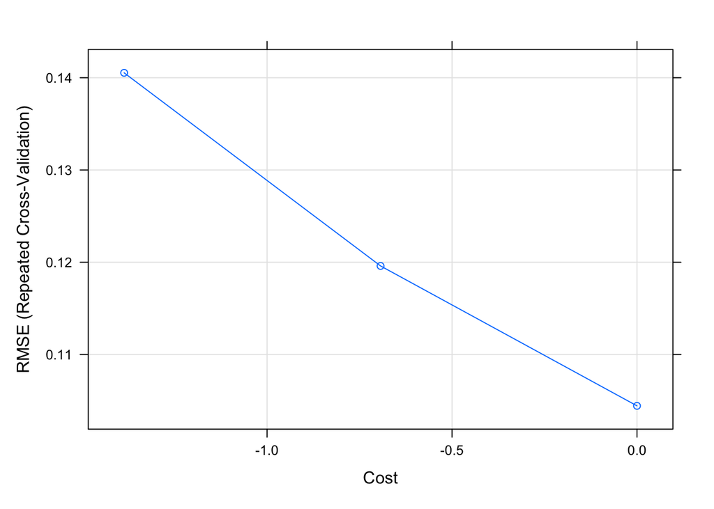

```r
plot(fit_svm_warmup, xTrans = log)
```

**SVM Tune grid**

```r
set.seed(1234)
svm_tune_grid <- expand.grid(
  .C = 2^seq(-5, 5, by = 1),
  .sigma = 2^seq(-15, -5, by = 1)
)

fit_svm_tune <- train(
  y ~ R + G + B + Hue + Saturation + Lightness,
  data = dfii,
  method = "svmRadial",
  metric = my_metric,
  preProcess = c("center", "scale"),
  trControl = my_ctrl,
  tuneGrid = svm_tune_grid
)
```

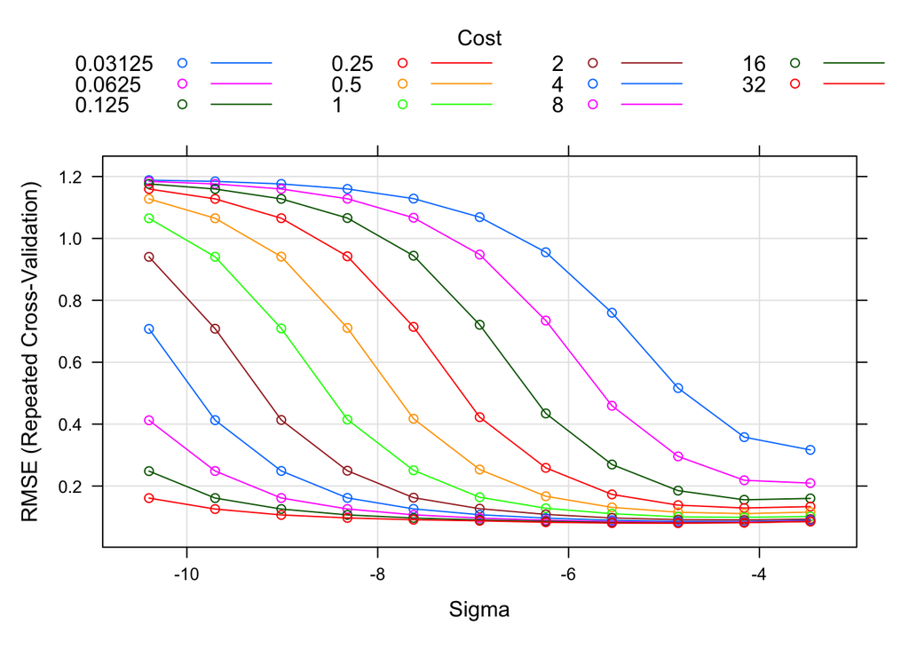

```r
plot(fit_svm_tune, xTrans = log)
```

#### PLS

```r
set.seed(1234)
fit_pls_warmup <- train(y ~ R + G + B + Hue + Saturation + Lightness,
                      data = dfii,
                      method = "pls",
                      metric = my_metric,
                      preProcess = c("center", "scale"),
                      trControl = my_ctrl)
```

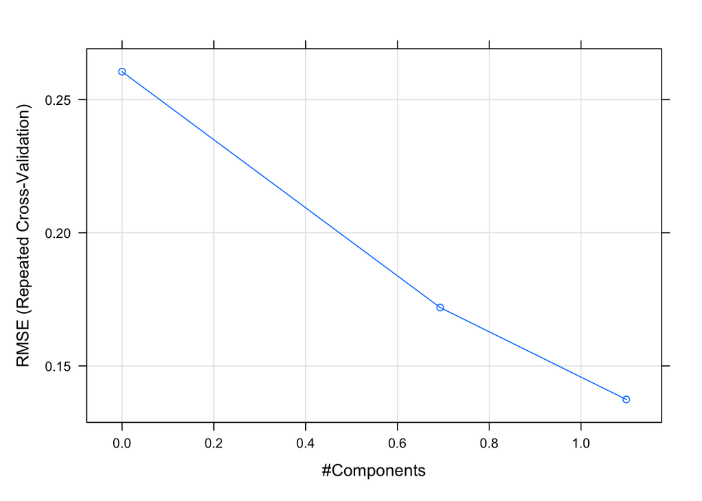

```r
plot(fit_pls_warmup, xTrans = log)
```

```r
set.seed(1234)
PLS_tuneGrid <- expand.grid(
  .ncomp = seq(1, 10, by = 1)
)

fit_pls_tune <- train(y ~ R + G + B + Hue + Saturation + Lightness,
                      data = dfii,
                      method = "pls",
                      metric = my_metric,
                      preProcess = c("center", "scale"),
                      trControl = my_ctrl,
                      tuneGrid = PLS_tuneGrid)
```

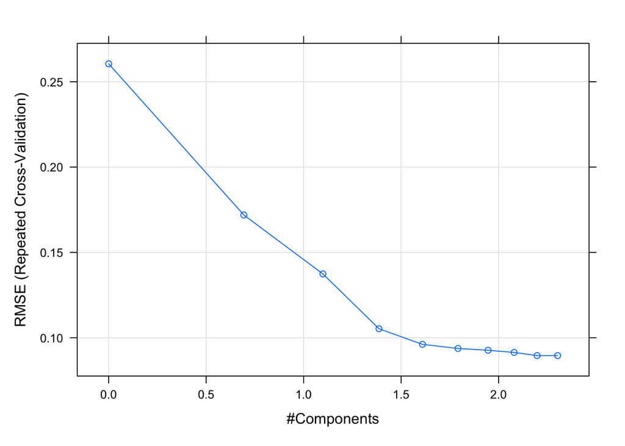

```r
plot(fit_pls_tune, xTrans = log)
```

### Compare the models

```r
my_performance <- resamples(list(FIT_LM_ADD = fit_lm_add,
                                 FIT_LM_PAIR = fit_lm_pair,
                                 FIT_LM_MOD6 = fit_lm_mod6,
                                 FIT_LM_MOD2 = fit_lm_mod2,
                                 ENET_PAIR_WARMUP = fit_enet_pair_warmup,
                                 ENET_PARI_TUNE = fit_enet_pair_add,
                                 ENET_MOD10_WARMUP = fit_enet_mod10_warmup,
                                 ENET_MOD10_TUNE = fit_enet_mod10_tune,
                                 ENET_MOD5_WARMUP = fit_enet_mod5_warmup,
                                 ENET_MOD5_TUNE = fit_enet_mod5_tune,
                                 NNET_WARMUP = fit_nnet_warmup,
                                 NNET_TUNE = fit_nnet_tune,
                                 RF_WARMUP = fit_rf_warmup,
                                 RF_TUNE = fit_rf_tune,
                                 GBM_WARMUP = fit_gbm_warmup,
                                 GBM_TUNE = fit_gbm_tune,
                                 SVM_WARMUP = fit_svm_warmup,
                                 SVM_TUNE = fit_svm_tune,
                                 PLS_WARMUP = fit_pls_warmup,
                                 PLS_TUNE = fit_pls_tune
                                 ))
```

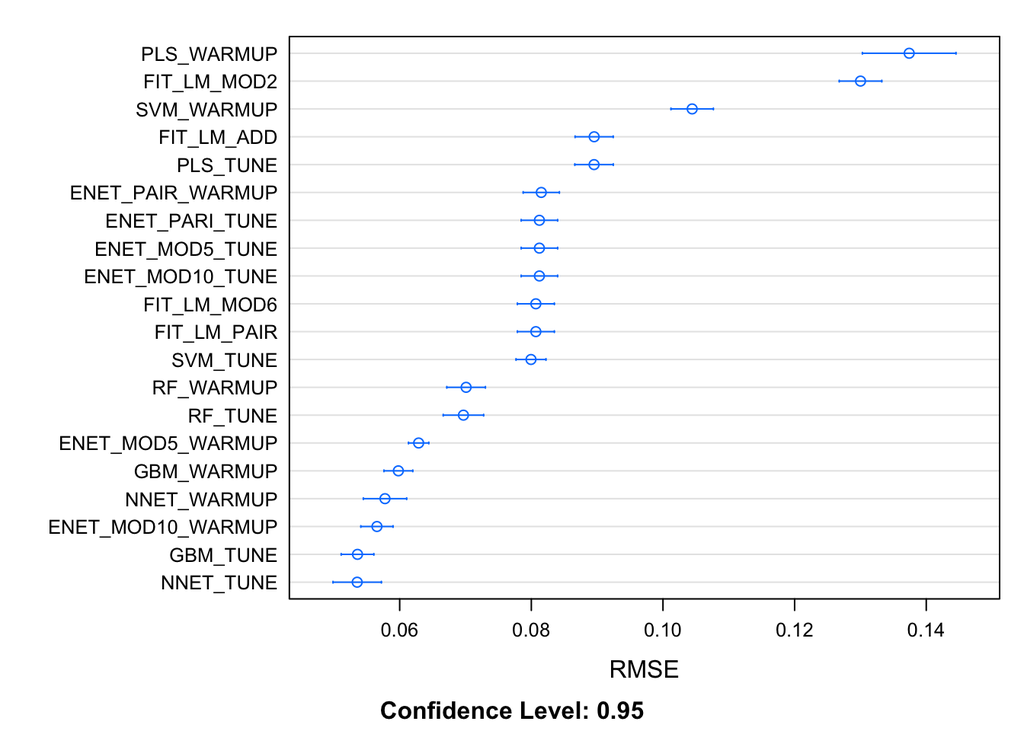

```r
dotplot(my_performance, metric = "RMSE", scales = 'free')
```

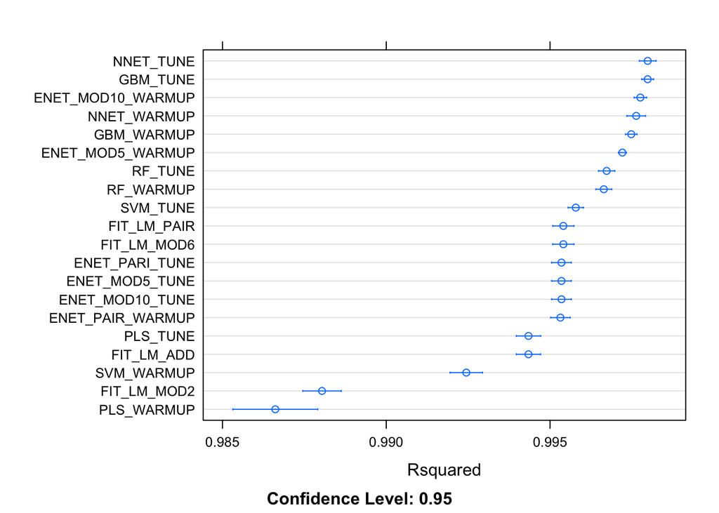

```r
dotplot(my_performance, metric = "Rsquared")
```

Which model is the best? According to the RMSE and Rsquared, NEET_TUNE is the best model.

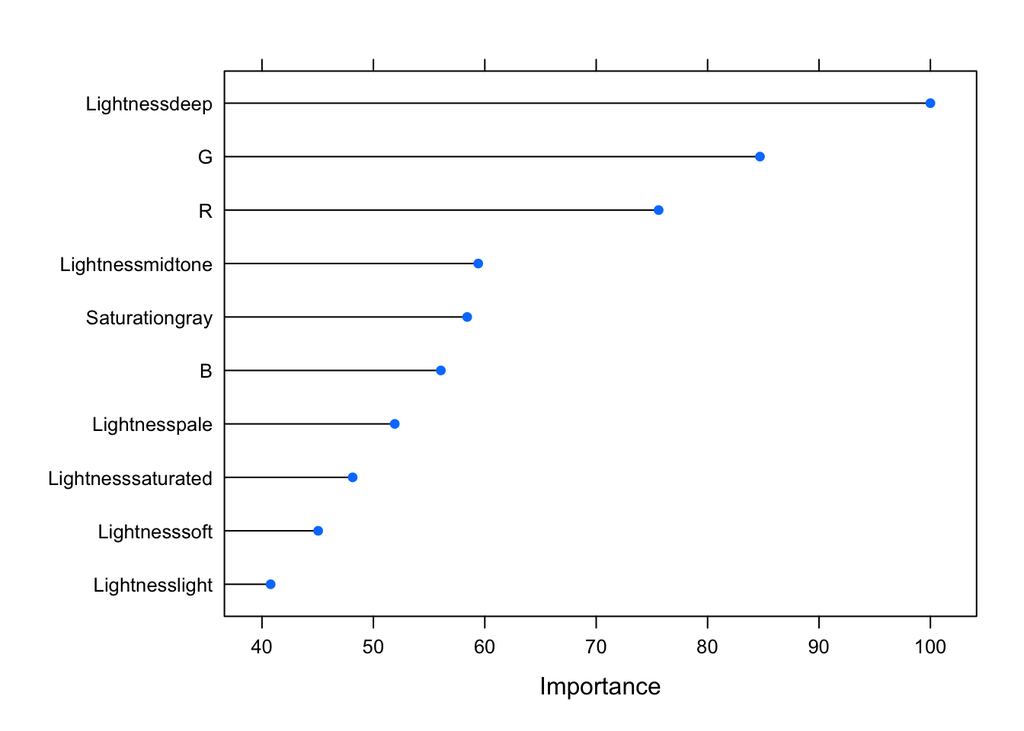

```r
plot(varImp(fit_nnet_tune), top = 10)
```

In NNET_TUNE model, Lightness-deep is the most important features.

```r
fit_nnet_tune %>% readr::write_rds("Model/fit_reg_nnet_tune.rds")
```